# Different Store Sales

This dataset contains 99,457 rows and 13 columns. It was downloaded from Kaggle and cleaned using Python/Pandas. The cleaned dataset was then imported into **SQL** Server for further analysis. **SQL** was used to perform data analysis and generate business insights.

```python
import kagglehub

# Download latest version
path = kagglehub.dataset_download("kzmontage/sales-from-different-stores")

print("Path to dataset files:", path)
```

```
Path to dataset files: C:\Users\USER\.cache\kagglehub\datasets\kzmontage\sales-from-different-stores\versions\2
```

```python
import os
print(os.listdir(path))
```

```
['Different_stores_dataset.csv', 'Different_stores_data_V2.csv']
```

```python
import pandas as pd
df = pd.read_csv(os.path.join(path, "Different_stores_dataset.csv"))
```

```python
df.head(7)
```

|  | invoice_no | invoice_date | customer_id | gender | age | category | quantity | selling_price_per_unit | cost_price_per_unit | payment_method | region | state | shopping_mall |
| --- | --- | --- | --- | --- | --- | --- | --- | --- | --- | --- | --- | --- | --- |
| 0 | I138884 | 10/30/2016 9:58 | C241288 | Female | 28 | Clothing | 5 | 1500.40 | 1425.380 | Credit Card | South | Kentucky | Kanyon |
| 1 | I317333 | 10/30/2016 9:58 | C111565 | Male | 21 | Shoes | 3 | 1800.51 | 1620.459 | Debit Card | South | Kentucky | Viaport Outlet |
| 2 | I127801 | 10/30/2016 9:58 | C266599 | Male | 20 | Clothing | 1 | 300.08 | 295.060 | Cash | West | California | Metrocity |
| 3 | I173702 | 10/30/2016 9:58 | C988172 | Female | 66 | Shoes | 5 | 3000.85 | 2900.765 | Credit Card | South | Florida | Metropol AVM |
| 4 | I337046 | 10/30/2016 9:59 | C189076 | Female | 53 | Books | 4 | 60.60 | 45.450 | Cash | South | Florida | Kanyon |
| 5 | I227836 | 10/30/2016 9:59 | C657758 | Female | 28 | Clothing | 5 | 1500.40 | 1475.380 | Credit Card | West | Oregon | Viaport Outlet |
| 6 | I121056 | 10/30/2016 9:59 | C151197 | Female | 49 | Cosmetics | 1 | 40.66 | 35.462 | Cash | West | California | Istinye Park |

# DATA CLEANING

**CHECKING SHAPE**

```python
df.shape
```

```
(99457, 13)
```

**CHECKING NULL**

```python
df.isnull().sum()
```

```
invoice_no                0
invoice_date              0
customer_id               0
gender                    0
age                       0
category                  0
quantity                  0
selling_price_per_unit    0
cost_price_per_unit       0
payment_method            0
region                    0
state                     0
shopping_mall             0
dtype: int64
```

**CHECKING DUPLICATES**

```python
df.duplicated().sum()
```

```
np.int64(0)
```

**CONVERTING COLUMNS TO TITLE CASE**

```python
df.columns = df.columns.str.title()
```

**CHECKING FOR NEGATIVE VALUES**

```python
df["Selling_Price_Per_Unit"] < 0
```

```
0        False
1        False
2        False
3        False
4        False
         ...
99452    False
99453    False
99454    False
99455    False
99456    False
Name: Selling_Price_Per_Unit, Length: 99457, dtype: bool
```

```python
df["Age"] < 0
```

```
0        False
1        False
2        False
3        False
4        False
         ...
99452    False
99453    False
99454    False
99455    False
99456    False
Name: Age, Length: 99457, dtype: bool
```

**CHECKING INCONSISTENCY**

```python
df.groupby("Invoice_No")["Invoice_Date"].nunique().max()
```

```
1
```

```python
df.groupby("Invoice_No")["Customer_Id"].nunique().max()
```

```
1
```

```python
df.groupby("Invoice_No")["Region"].nunique().max()
```

```
1
```

**CHECKING FOR UNIQUE VALUES**

```python
df["Region"].unique()
```

```
array(['South', 'West', 'Central', 'East'], dtype=object)
```

```python
df["Payment_Method"].unique()
```

```
array(['Credit Card', 'Debit Card', 'Cash'], dtype=object)
```

```python
df["Gender"].unique()
```

```
array(['Female', 'Male'], dtype=object)
```

# DATASET CHECKED THOROUGHLY

- **NULL VALUES:** None found
- **DUPLICATES:** None found
- **UNIQUE VALUES:** No unusual or inconsistent unique values found
- **INCONSISTENCIES:** None found

**The dataset is clean and ready for further analysis using SQL queries.**

```python
import pyodbc
```

```python
conn = pyodbc.connect(
"DRIVER={ODBC Driver 17 for SQL Server};"
"SERVER=DESKTOP-KRJR07A\SQLEXPRESS;"
"DATABASE=STORE_DATA;"
"Trusted_connection=yes;"
)
print("connected")
```

```
connected
```

```python
from sqlalchemy import create_engine
from urllib.parse import quote_plus
params = quote_plus(
"DRIVER={ODBC Driver 17 for SQL Server};"
"SERVER=DESKTOP-KRJR07A\SQLEXPRESS;"
"DATABASE=STORE_DATA;"
"Trusted_connection=yes;"
)

engine = create_engine("mssql+pyodbc:///?odbc_connect="+params)
```

```python
df.to_sql("Different_stores_dataset", engine, if_exists="replace", index=False)
```

```
120
```

# SQL

```python
pd.read_sql("""
SELECT TABLE_NAME
FROM INFORMATION_SCHEMA.TABLES
WHERE TABLE_TYPE = 'BASE TABLE'


""",engine)
```

|  | TABLE_NAME |
| --- | --- |
| 0 | Sample_Superstore |
| 1 | customers |
| 2 | deliveries |
| 3 | orders |
| 4 | restaurants |
| 5 | riders. |
| 6 | kiez_prices_monthly |
| 7 | new_construction |
| 8 | rentals |
| 9 | secondary_sales |
| 10 | transit_stations.csv |
| 11 | marketing_sales_dataset |
| 12 | mango_sales_100000 |
| 13 | Different_stores_dataset |
| 14 | amazon_sales_data |

```python
pd.read_sql("""

SELECT TOP 7 *
FROM Different_stores_dataset

""", engine)
```

|  | Invoice_No | Invoice_Date | Customer_Id | Gender | Age | Category | Quantity | Selling_Price_Per_Unit | Cost_Price_Per_Unit | Payment_Method | Region | State | Shopping_Mall |
| --- | --- | --- | --- | --- | --- | --- | --- | --- | --- | --- | --- | --- | --- |
| 0 | I322215 | 11/6/2016 12:10 | C123286 | Male | 23 | Cosmetics | 4 | 162.64 | 130.112 | Cash | South | North Carolina | Metrocity |
| 1 | I286726 | 11/6/2016 12:10 | C576442 | Female | 22 | Clothing | 5 | 1500.40 | 1425.380 | Cash | South | North Carolina | Metropol AVM |
| 2 | I257461 | 11/6/2016 12:10 | C231862 | Male | 38 | Food & Beverage | 3 | 15.69 | 10.983 | Credit Card | Central | Texas | Metrocity |
| 3 | I181730 | 11/6/2016 12:10 | C849818 | Female | 31 | Clothing | 4 | 1200.32 | 1140.304 | Credit Card | West | California | Istinye Park |
| 4 | I242232 | 11/6/2016 12:11 | C288411 | Female | 56 | Clothing | 1 | 300.08 | 225.060 | Credit Card | Central | Iowa | Viaport Outlet |
| 5 | I160901 | 11/6/2016 12:11 | C627693 | Female | 63 | Toys | 1 | 35.84 | 25.088 | Cash | Central | Iowa | Kanyon |
| 6 | I132360 | 11/6/2016 12:11 | C195161 | Female | 31 | Souvenir | 2 | 23.46 | 16.422 | Credit Card | West | California | Istinye Park |

**CREATING COLUMNS – DAY_NAME, MONTH_NAME, PROFIT, PROFIT_MARGIN**

```python
cursor = conn.cursor()
cursor.execute("""
ALTER  TABLE Different_stores_dataset
ADD Day_Name VARCHAR(20), Month_Name VARCHAR(20), Profit DECIMAL(20, 2), Profit_Margin DECIMAL(10, 2)


""")
conn.commit()
```

```python
cursor = conn.cursor()
cursor.execute("""
UPDATE Different_stores_dataset
SET
    Day_Name = DATENAME(WEEKDAY, Invoice_Date),
    Month_Name = DATENAME(MONTH, Invoice_Date),
    Profit = (Selling_Price_Per_Unit - Cost_Price_Per_Unit) * Quantity,
    Profit_Margin =
        ((Selling_Price_Per_Unit - Cost_Price_Per_Unit)
        / NULLIF(Selling_Price_Per_Unit, 0)) * 100
""")

conn.commit()
```

**CHECKING COLUMN NAMES**

```python
pd.read_sql("""
SELECT COLUMN_NAME
FROM INFORMATION_SCHEMA.COLUMNS
WHERE TABLE_NAME = 'Different_stores_dataset'



""",engine)
```

|  | COLUMN_NAME |
| --- | --- |
| 0 | Invoice_No |
| 1 | Invoice_Date |
| 2 | Customer_Id |
| 3 | Gender |
| 4 | Age |
| 5 | Category |
| 6 | Quantity |
| 7 | Selling_Price_Per_Unit |
| 8 | Cost_Price_Per_Unit |
| 9 | Payment_Method |
| 10 | Region |
| 11 | State |
| 12 | Shopping_Mall |
| 13 | Day_Name |
| 14 | Month_Name |
| 15 | Profit |
| 16 | Profit_Margin |

**TOTAL SALES**

```python
pd.read_sql("""
SELECT FORMAT(SUM(Selling_Price_Per_Unit*Quantity), 'N0') AS TOTAL_SALES
FROM Different_stores_dataset
""", engine)
```

|  | TOTAL_SALES |
| --- | --- |
| 0 | 251,565,248 |

**TOTAL PROFIT**

```python
pd.read_sql("""
SELECT SUM(Profit) AS TOTAL_PROFIT
FROM Different_stores_dataset

""",engine)
```

|  | TOTAL_PROFIT |
| --- | --- |
| 0 | 26588127.53 |

**OVERALL PROFIT MARGIN**

```python
pd.read_sql("""

SELECT
    ROUND(
        SUM(Profit) / NULLIF(SUM(Selling_Price_Per_Unit*Quantity), 0) * 100,
        2
    ) AS OVERALL_PROFIT_MARGIN
FROM Different_stores_dataset;

""",engine)
```

|  | OVERALL_PROFIT_MARGIN |
| --- | --- |
| 0 | 10.57 |

**TOP 10 CUSTOMERS BY SALES AND PROFIT**

```python
pd.read_sql("""

SELECT TOP 10 Customer_Id,
SUM(Selling_Price_Per_Unit*Quantity) TOTAL_SALES,
SUM(Profit) AS TOTAL_PROFIT
FROM Different_stores_dataset
GROUP BY Customer_Id
ORDER BY TOTAL_SALES DESC, TOTAL_PROFIT DESC;


""",engine)
```

|  | Customer_Id | TOTAL_SALES | TOTAL_PROFIT |
| --- | --- | --- | --- |
| 0 | C189493 | 47250.0 | 7087.5 |
| 1 | C100168 | 26250.0 | 2625.0 |
| 2 | C100306 | 26250.0 | 2625.0 |
| 3 | C100322 | 26250.0 | 2625.0 |
| 4 | C100607 | 26250.0 | 2625.0 |
| 5 | C101216 | 26250.0 | 2625.0 |
| 6 | C101344 | 26250.0 | 2625.0 |
| 7 | C101427 | 26250.0 | 2625.0 |
| 8 | C101667 | 26250.0 | 2625.0 |
| 9 | C101788 | 26250.0 | 2625.0 |

**SALES AND PROFIT BY GENDER**

```python
pd.read_sql("""
SELECT
    Gender,
    FORMAT(SUM(Selling_Price_Per_Unit*Quantity), 'N0') AS TOTAL_SALES,
    FORMAT(SUM(Profit), 'N0') AS TOTAL_PROFIT
FROM Different_stores_dataset
GROUP BY Gender
ORDER BY SUM(Selling_Price_Per_Unit*Quantity) DESC, SUM(Profit) DESC;
""", engine)
```

|  | Gender | TOTAL_SALES | TOTAL_PROFIT |
| --- | --- | --- | --- |
| 0 | Female | 150,216,945 | 15,874,477 |
| 1 | Male | 101,348,303 | 10,713,651 |

**TOP 10 AGE GROUPS BY SALES AND PROFIT**

```python
pd.read_sql("""

SELECT TOP 10 Age,
SUM(Selling_Price_Per_Unit*Quantity) TOTAL_SALES,
SUM(Profit) AS TOTAL_PROFIT
FROM Different_stores_dataset
GROUP BY Age
ORDER BY TOTAL_SALES DESC, TOTAL_PROFIT DESC;


""",engine)
```

|  | Age | TOTAL_SALES | TOTAL_PROFIT |
| --- | --- | --- | --- |
| 0 | 37 | 5579271.45 | 574981.11 |
| 1 | 64 | 5272475.10 | 549949.59 |
| 2 | 51 | 5238724.74 | 550365.66 |
| 3 | 22 | 5208841.41 | 565288.42 |
| 4 | 27 | 5174859.86 | 538179.69 |
| 5 | 39 | 5136160.69 | 551237.52 |
| 6 | 48 | 5131747.86 | 529094.50 |
| 7 | 44 | 5131686.80 | 547368.53 |
| 8 | 43 | 5088123.72 | 531559.35 |
| 9 | 24 | 5082409.90 | 534505.27 |

**SALES AND PROFIT BY CATEGORY**

```python
pd.read_sql("""

SELECT Category,
FORMAT(SUM(Selling_Price_Per_Unit*Quantity), 'N0') AS TOTAL_SALES,
FORMAT(SUM(Profit), 'N0') AS TOTAL_PROFIT
FROM Different_stores_dataset
GROUP BY Category
ORDER BY SUM(Selling_Price_Per_Unit*Quantity) DESC, SUM(Profit) DESC;


""",engine)
```

|  | Category | TOTAL_SALES | TOTAL_PROFIT |
| --- | --- | --- | --- |
| 0 | Clothing | 114,014,496 | 11,510,626 |
| 1 | Shoes | 66,553,451 | 5,858,531 |
| 2 | Technology | 57,900,150 | 6,268,658 |
| 3 | Cosmetics | 6,796,685 | 1,475,550 |
| 4 | Toys | 3,980,426 | 864,786 |
| 5 | Food & Beverage | 849,556 | 223,263 |
| 6 | Books | 834,659 | 219,243 |
| 7 | Souvenir | 635,825 | 167,472 |

**QUANTITY BY CATEGORY**

```python
pd.read_sql("""
SELECT
    Category,
    SUM(Quantity) AS TOTAL_QUANTITY
FROM Different_stores_dataset
GROUP BY Category
ORDER BY TOTAL_QUANTITY DESC;


""",engine)
```

|  | Category | TOTAL_QUANTITY |
| --- | --- | --- |
| 0 | Clothing | 103598 |
| 1 | Cosmetics | 45501 |
| 2 | Food & Beverage | 44281 |
| 3 | Toys | 30321 |
| 4 | Shoes | 30217 |
| 5 | Technology | 15033 |
| 6 | Books | 14989 |
| 7 | Souvenir | 14871 |

**SALES, PROFIT AND COUNT BY PAYMENT_METHOD**

```python
pd.read_sql("""

SELECT
    Payment_Method,
    FORMAT(SUM(Selling_Price_Per_Unit * Quantity), 'N0') AS TOTAL_SALES,
    FORMAT(SUM(Profit), 'N0') AS TOTAL_PROFIT,
    COUNT(*) AS TOTAL_COUNT
FROM Different_stores_dataset
GROUP BY Payment_Method
ORDER BY SUM(Selling_Price_Per_Unit*Quantity) DESC, SUM(Profit) DESC;


""",engine)
```

|  | Payment_Method | TOTAL_SALES | TOTAL_PROFIT | TOTAL_COUNT |
| --- | --- | --- | --- | --- |
| 0 | Cash | 112,843,578 | 11,911,875 | 44447 |
| 1 | Credit Card | 88,122,541 | 9,335,053 | 34931 |
| 2 | Debit Card | 50,599,128 | 5,341,199 | 20079 |

**SALES AND PROFIT BY REGION**

```python
pd.read_sql("""

SELECT
    Region,
    FORMAT(SUM(Selling_Price_Per_Unit * Quantity), 'N0') AS TOTAL_SALES,
    FORMAT(SUM(Profit), 'N0') AS TOTAL_PROFIT
FROM Different_stores_dataset
GROUP BY Region
ORDER BY SUM(Selling_Price_Per_Unit*Quantity) DESC, SUM(Profit) DESC;

""",engine)
```

|  | Region | TOTAL_SALES | TOTAL_PROFIT |
| --- | --- | --- | --- |
| 0 | West | 79,825,624 | 8,411,593 |
| 1 | East | 72,280,661 | 7,674,469 |
| 2 | Central | 58,803,472 | 6,198,839 |
| 3 | South | 40,655,492 | 4,303,227 |

**TOP 10 STATES BY SALES AND PROFIT**

```python
pd.read_sql("""
SELECT TOP 10
    State,
   FORMAT(SUM(Selling_Price_Per_Unit * Quantity), 'N0') AS TOTAL_SALES,
   FORMAT(SUM(Profit), 'N0') AS TOTAL_PROFIT
FROM Different_stores_dataset
GROUP BY State
ORDER BY SUM(Selling_Price_Per_Unit*Quantity) DESC, SUM(Profit) DESC;


""",engine)
```

|  | State | TOTAL_SALES | TOTAL_PROFIT |
| --- | --- | --- | --- |
| 0 | California | 48,014,603 | 5,091,161 |
| 1 | New York | 29,344,728 | 3,102,234 |
| 2 | Texas | 24,842,175 | 2,626,599 |
| 3 | Pennsylvania | 15,021,619 | 1,599,584 |
| 4 | Illinois | 12,674,594 | 1,332,296 |
| 5 | Washington | 12,626,613 | 1,309,631 |
| 6 | Ohio | 11,457,412 | 1,235,729 |
| 7 | Iowa | 11,392,717 | 1,189,427 |
| 8 | Delaware | 9,484,681 | 1,016,200 |
| 9 | Florida | 9,441,508 | 995,854 |

**SALES AND PROFIT BY SHOPPING_MALL**

```python
pd.read_sql("""

SELECT
    Shopping_Mall,
    FORMAT(SUM(Selling_Price_Per_Unit * Quantity), 'N0') AS TOTAL_SALES,
    FORMAT(SUM(Profit), 'N0') AS TOTAL_PROFIT
FROM Different_stores_dataset
GROUP BY Shopping_Mall
ORDER BY SUM(Selling_Price_Per_Unit*Quantity) DESC, SUM(Profit) DESC;

""",engine)
```

|  | Shopping_Mall | TOTAL_SALES | TOTAL_PROFIT |
| --- | --- | --- | --- |
| 0 | Kanyon | 50,560,908 | 5,315,542 |
| 1 | Mall of Istanbul | 49,105,588 | 5,195,894 |
| 2 | Metrocity | 37,302,787 | 3,967,531 |
| 3 | Istinye Park | 37,272,514 | 3,915,354 |
| 4 | Zorlu Center | 26,180,229 | 2,771,461 |
| 5 | Viaport Outlet | 25,763,309 | 2,734,048 |
| 6 | Metropol AVM | 25,379,913 | 2,688,297 |

**SALES BY DAY IN EACH MONTH AND YEAR**

```python
pd.read_sql("""

SELECT
    YEAR(Invoice_Date) AS YEAR,
    Month_Name,
    Day_Name,
    FORMAT(SUM(Selling_Price_Per_Unit * Quantity), 'N0') AS TOTAL_SALES
FROM Different_stores_dataset
GROUP BY YEAR(Invoice_Date), Month_Name, Day_Name
ORDER BY SUM(Selling_Price_Per_Unit * Quantity) DESC;

""", engine)
```

|  | YEAR | Month_Name | Day_Name | TOTAL_SALES |
| --- | --- | --- | --- | --- |
| 0 | 2016 | November | Tuesday | 38,692,046 |
| 1 | 2016 | November | Sunday | 31,721,168 |
| 2 | 2016 | November | Saturday | 31,603,015 |
| 3 | 2016 | November | Friday | 31,422,019 |
| 4 | 2016 | November | Thursday | 31,222,966 |
| 5 | 2016 | November | Wednesday | 30,918,673 |
| 6 | 2016 | November | Monday | 30,654,738 |
| 7 | 2016 | October | Monday | 15,832,272 |
| 8 | 2016 | October | Sunday | 9,498,350 |

**SALES AND PROFIT BY DAY**

```python
pd.read_sql("""
SELECT Day_Name,
FORMAT(SUM(Selling_Price_Per_Unit*Quantity), 'N0') AS TOTAL_SALES,
FORMAT(SUM(Profit), 'N0') AS TOTAL_PROFIT
FROM Different_stores_dataset
GROUP BY Day_Name
ORDER BY SUM(Selling_Price_Per_Unit*Quantity) DESC, SUM(Profit) DESC;


""",engine)
```

|  | Day_Name | TOTAL_SALES | TOTAL_PROFIT |
| --- | --- | --- | --- |
| 0 | Monday | 46,487,011 | 4,915,468 |
| 1 | Sunday | 41,219,519 | 4,343,385 |
| 2 | Tuesday | 38,692,046 | 4,080,074 |
| 3 | Saturday | 31,603,015 | 3,337,124 |
| 4 | Friday | 31,422,019 | 3,330,162 |
| 5 | Thursday | 31,222,966 | 3,294,660 |
| 6 | Wednesday | 30,918,673 | 3,287,255 |

**SALES BY MONTH IN EACH YEAR**

```python
pd.read_sql("""
SELECT
    YEAR(Invoice_Date) AS YEAR,
    Month_Name,
    FORMAT(SUM(Selling_Price_Per_Unit * Quantity), 'N0') AS TOTAL_SALES
FROM Different_stores_dataset
GROUP BY YEAR(Invoice_Date), Month_Name
ORDER BY YEAR, SUM(Selling_Price_Per_Unit * Quantity) DESC;


""", engine)
```

|  | YEAR | Month_Name | TOTAL_SALES |
| --- | --- | --- | --- |
| 0 | 2016 | November | 226,234,625 |
| 1 | 2016 | October | 25,330,623 |

**SALES AND PROFIT BY MONTH**

```python
pd.read_sql("""
SELECT Month_Name,
FORMAT(SUM(Selling_Price_Per_Unit*Quantity), 'N0') AS TOTAL_SALES,
FORMAT(SUM(Profit), 'N0') AS TOTAL_PROFIT
FROM Different_stores_dataset
GROUP BY Month_Name
ORDER BY SUM(Selling_Price_Per_Unit*Quantity) DESC, SUM(Profit) DESC;


""", engine)
```

|  | Month_Name | TOTAL_SALES | TOTAL_PROFIT |
| --- | --- | --- | --- |
| 0 | November | 226,234,625 | 23,920,281 |
| 1 | October | 25,330,623 | 2,667,846 |

**FIRST AND LAST INVOICE DATE**

```python
pd.read_sql("""

SELECT
    MIN(Invoice_Date) AS FIRST_DATE,
    MAX(Invoice_Date) AS LAST_DATE
FROM Different_stores_dataset;

""", engine)
```

|  | FIRST_DATE | LAST_DATE |
| --- | --- | --- |
| 0 | 10/30/2016 10:00 | 11/9/2016 9:59 |

```python
import matplotlib.pyplot as plt
import seaborn as sns


sns.set_style("whitegrid")
plt.rcParams['figure.figsize'] = (10, 6)
```

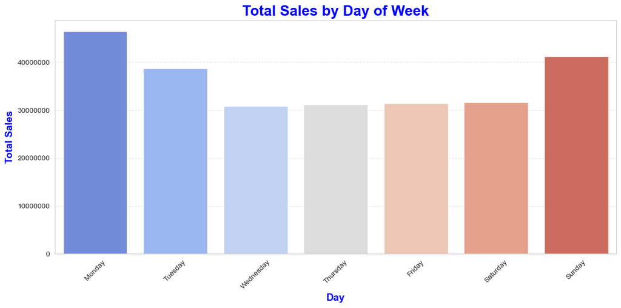

```python
df_day = pd.read_sql("""
SELECT Day_Name,
SUM(Selling_Price_Per_Unit*Quantity) AS TOTAL_SALES
FROM Different_stores_dataset
GROUP BY Day_Name;
""", engine)

day_order = ['Monday','Tuesday','Wednesday','Thursday','Friday','Saturday','Sunday']
df_day['Day_Name'] = pd.Categorical(df_day['Day_Name'], categories=day_order, ordered=True)
df_day = df_day.sort_values('Day_Name')

plt.figure(figsize=(12, 6))
sns.barplot(data=df_day, x='Day_Name', y='TOTAL_SALES', hue='Day_Name', legend=False, palette='coolwarm')
plt.title('Total Sales by Day of Week', color="blue", fontsize=20, fontweight="bold")
plt.xlabel('Day', color="blue", fontsize=14, fontweight="bold")
plt.ylabel('Total Sales', color="blue", fontsize=14, fontweight="bold")
plt.ticklabel_format(style="plain", axis="y")
plt.grid(axis="y", linestyle="--", alpha=0.5)
plt.xticks(rotation=45)
plt.tight_layout()
plt.show()
```

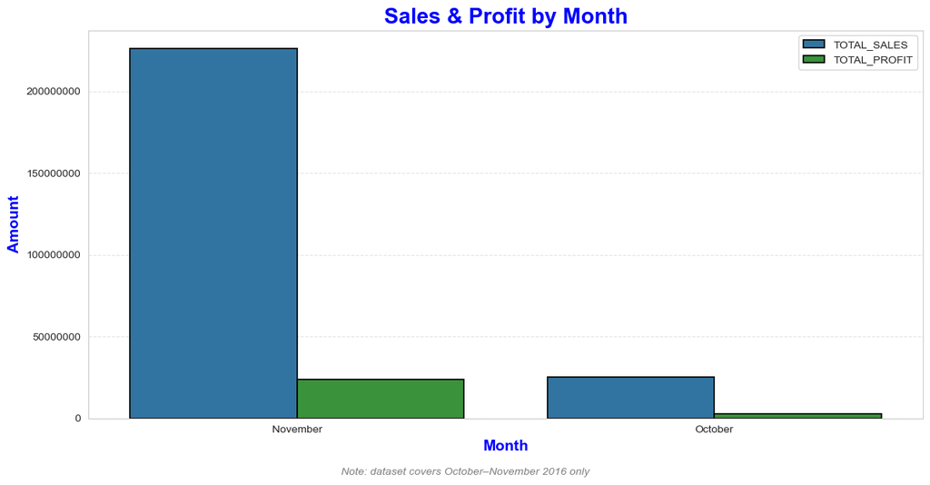

```python
SALES_PROFIT_MONTH = pd.read_sql("""
SELECT Month_Name,
SUM(Selling_Price_Per_Unit*Quantity) AS TOTAL_SALES,
SUM(Profit) AS TOTAL_PROFIT
FROM Different_stores_dataset
GROUP BY Month_Name
ORDER BY TOTAL_SALES DESC;
""", engine)

df_melted = SALES_PROFIT_MONTH.melt(id_vars="Month_Name", value_vars=["TOTAL_SALES", "TOTAL_PROFIT"],
                                     var_name="Metric", value_name="Amount")

plt.figure(figsize=(12, 6))
sns.barplot(data=df_melted, x='Month_Name', y='Amount', hue='Metric', palette=['#1f77b4', '#2ca02c'], edgecolor="black", linewidth=1.2)

plt.title('Sales & Profit by Month', color="blue", fontsize=20, fontweight="bold")
plt.xlabel('Month', color="blue", fontsize=14, fontweight="bold")
plt.ylabel('Amount', color="blue", fontsize=14, fontweight="bold")
plt.ticklabel_format(style="plain", axis="y")
plt.grid(axis="y", linestyle="--", alpha=0.5)
plt.legend(title="")
plt.figtext(0.5, -0.02, "Note: dataset covers October–November 2016 only", ha="center", fontsize=10, style="italic", color="gray")
plt.tight_layout()
plt.show()
```

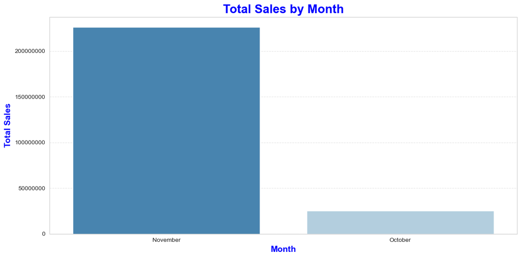

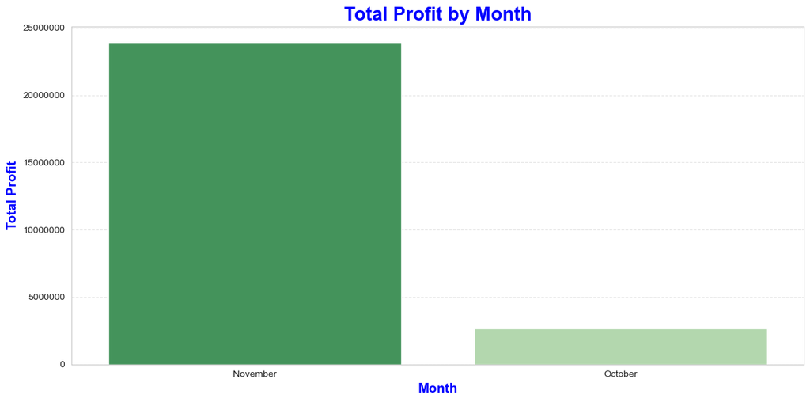

```python
SALES_PROFIT_MONTH = pd.read_sql("""
SELECT Month_Name,
SUM(Selling_Price_Per_Unit*Quantity) AS TOTAL_SALES,
SUM(Profit) AS TOTAL_PROFIT
FROM Different_stores_dataset
GROUP BY Month_Name
ORDER BY TOTAL_SALES DESC;
""", engine)

# Chart 1: Sales
plt.figure(figsize=(12, 6))
sns.barplot(data=SALES_PROFIT_MONTH, x='Month_Name', y='TOTAL_SALES', hue='Month_Name', legend=False, palette='Blues_r')
plt.title('Total Sales by Month', color="blue", fontsize=20, fontweight="bold")
plt.xlabel('Month', color="blue", fontsize=14, fontweight="bold")
plt.ylabel('Total Sales', color="blue", fontsize=14, fontweight="bold")
plt.ticklabel_format(style="plain", axis="y")
plt.grid(axis="y", linestyle="--", alpha=0.5)
plt.tight_layout()
plt.show()

# Chart 2: Profit
plt.figure(figsize=(12, 6))
sns.barplot(data=SALES_PROFIT_MONTH, x='Month_Name', y='TOTAL_PROFIT', hue='Month_Name', legend=False, palette='Greens_r')
plt.title('Total Profit by Month', color="blue", fontsize=20, fontweight="bold")
plt.xlabel('Month', color="blue", fontsize=14, fontweight="bold")
plt.ylabel('Total Profit', color="blue", fontsize=14, fontweight="bold")
plt.ticklabel_format(style="plain", axis="y")
plt.grid(axis="y", linestyle="--", alpha=0.5)
plt.tight_layout()
plt.show()
```

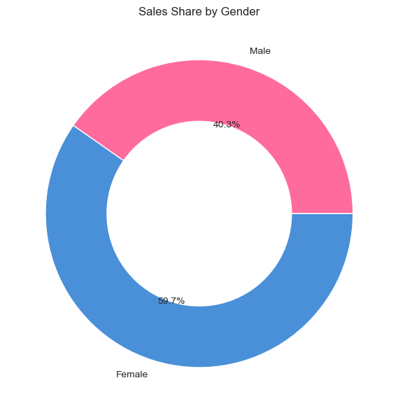

```python
df_gender = pd.read_sql("""
SELECT Gender,
SUM(Selling_Price_Per_Unit*Quantity) AS TOTAL_SALES
FROM Different_stores_dataset
GROUP BY Gender;
""", engine)

plt.figure()
plt.pie(df_gender['TOTAL_SALES'], labels=df_gender['Gender'], autopct='%1.1f%%',
        colors=['#FF6B9D','#4A90D9'], wedgeprops={'width':0.4})
plt.title('Sales Share by Gender')
plt.tight_layout()
plt.show()
```

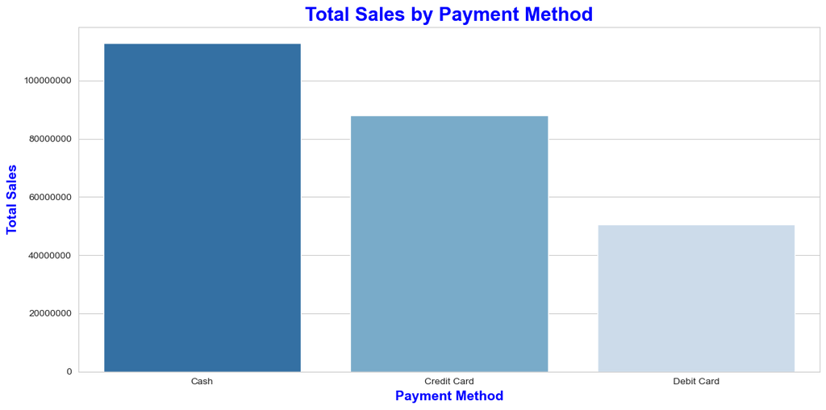

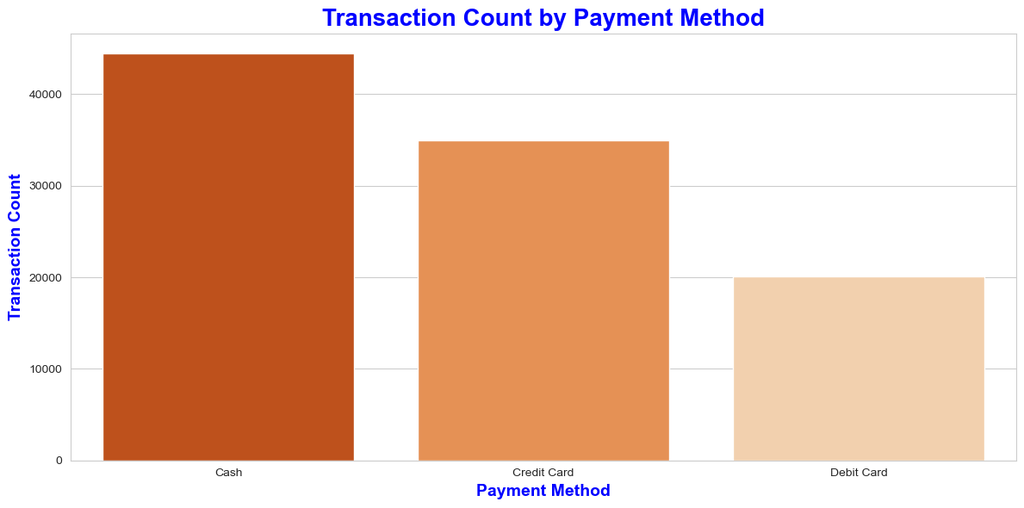

```python
df_pay = pd.read_sql("""
SELECT Payment_Method,
SUM(Selling_Price_Per_Unit*Quantity) AS TOTAL_SALES,
COUNT(*) AS TOTAL_COUNT
FROM Different_stores_dataset
GROUP BY Payment_Method
ORDER BY TOTAL_SALES DESC;
""", engine)

# Chart 1: Sales
plt.figure(figsize=(12, 6))
sns.barplot(data=df_pay, x='Payment_Method', y='TOTAL_SALES', hue='Payment_Method', legend=False, palette='Blues_r')
plt.title('Total Sales by Payment Method', color="blue", fontsize=20, fontweight="bold")
plt.xlabel('Payment Method', color="blue", fontsize=14, fontweight="bold")
plt.ylabel('Total Sales', color="blue", fontsize=14, fontweight="bold")
plt.ticklabel_format(style="plain", axis="y")
plt.tight_layout()
plt.show()

# Chart 2: Transaction Count
plt.figure(figsize=(12, 6))
sns.barplot(data=df_pay, x='Payment_Method', y='TOTAL_COUNT', hue='Payment_Method', legend=False, palette='Oranges_r')
plt.title('Transaction Count by Payment Method', color="blue", fontsize=20, fontweight="bold")
plt.xlabel('Payment Method', color="blue", fontsize=14, fontweight="bold")
plt.ylabel('Transaction Count', color="blue", fontsize=14, fontweight="bold")
plt.ticklabel_format(style="plain", axis="y")
plt.tight_layout()
plt.show()
```

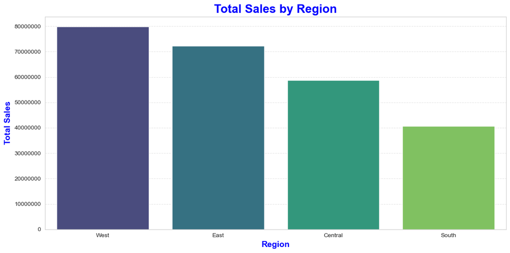

```python
df_region = pd.read_sql("""
SELECT Region,
SUM(Selling_Price_Per_Unit*Quantity) AS TOTAL_SALES
FROM Different_stores_dataset
GROUP BY Region
ORDER BY TOTAL_SALES DESC;
""", engine)

plt.figure(figsize=(12, 6))
sns.barplot(data=df_region, x='Region', y='TOTAL_SALES', hue='Region', legend=False, palette='viridis')
plt.title('Total Sales by Region', color="blue", fontsize=20, fontweight="bold")
plt.xlabel('Region', color="blue", fontsize=14, fontweight="bold")
plt.ylabel('Total Sales', color="blue", fontsize=14, fontweight="bold")
plt.ticklabel_format(style="plain", axis="y")
plt.grid(axis="y", linestyle="--", alpha=0.5)
plt.tight_layout()
plt.show()
```

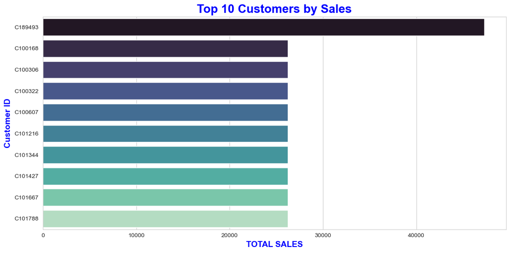

```python
df_cust = pd.read_sql("""
SELECT TOP 10 Customer_Id,
SUM(Selling_Price_Per_Unit*Quantity) AS TOTAL_SALES
FROM Different_stores_dataset
GROUP BY Customer_Id
ORDER BY TOTAL_SALES DESC;
""", engine)

plt.figure(figsize=(12, 6))
sns.barplot(data=df_cust, y='Customer_Id', x='TOTAL_SALES', hue='Customer_Id', legend=False, palette='mako')
plt.title('Top 10 Customers by Sales', color="blue", fontsize=20, fontweight="bold")
plt.xlabel('TOTAL SALES', color="blue", fontsize=14, fontweight="bold")
plt.ylabel('Customer ID', color="blue", fontsize=14, fontweight="bold")
plt.ticklabel_format(style="plain", axis="x")
plt.tight_layout()
plt.show()
```

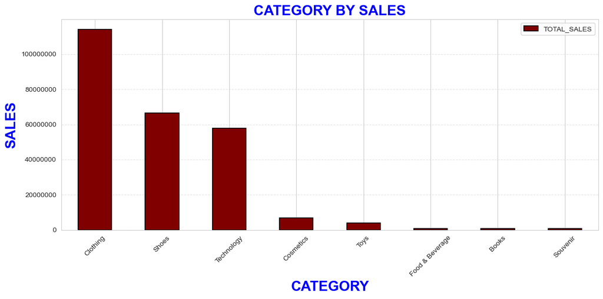

```python
SALES_BY_CATEGORY = pd.read_sql("""

SELECT Category,
SUM(Selling_Price_Per_Unit*Quantity) AS TOTAL_SALES
FROM Different_stores_dataset
GROUP BY Category
ORDER BY SUM(Selling_Price_Per_Unit*Quantity) DESC;

""", engine)

SALES_BY_CATEGORY.plot.bar(x="Category", y="TOTAL_SALES", color="maroon", edgecolor="black", linewidth=1.2, figsize=(12, 6))

plt.title("CATEGORY BY SALES", color="blue", fontsize=20, fontweight="bold")
plt.xlabel("CATEGORY", color="blue", fontsize=20, fontweight="bold")
plt.ylabel("SALES", color="blue", fontsize=20, fontweight="bold")

plt.ticklabel_format(style="plain", axis="y")
plt.xticks(rotation=45)
plt.grid(axis="y", linestyle="--", alpha=0.5)

plt.tight_layout()
plt.show()
```

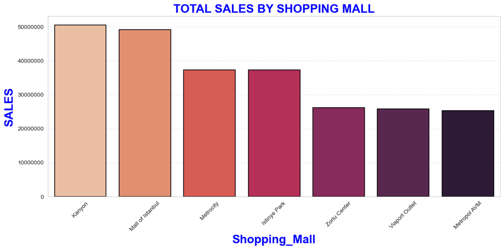

```python
SALES_BY_MALL = pd.read_sql("""

SELECT Shopping_Mall,
SUM(Selling_Price_Per_Unit*Quantity) AS TOTAL_SALES
FROM Different_stores_dataset
GROUP BY Shopping_Mall
ORDER BY SUM(Selling_Price_Per_Unit*Quantity) DESC;

""", engine)

plt.figure(figsize=(12, 6))
sns.barplot(
    data=SALES_BY_MALL,
    x="Shopping_Mall", y="TOTAL_SALES",
    hue="Shopping_Mall", legend=False,
    edgecolor="black", linewidth=1.2, palette="rocket_r"
)

plt.title("TOTAL SALES BY SHOPPING MALL", color="blue", fontsize=20, fontweight="bold")
plt.xlabel("Shopping_Mall", color="blue", fontsize=20, fontweight="bold")
plt.ylabel("SALES", color="blue", fontsize=20, fontweight="bold")

plt.ticklabel_format(style="plain", axis="y")
plt.xticks(rotation=45)
plt.grid(axis="y", linestyle="--", alpha=0.5)

plt.tight_layout()
plt.show()
```

# CONCLUSION

1. **C189493** recorded the highest individual customer sales of **47,250** and profit of **7,087.50**.
2. The dataset generated **251,565,248** in total sales, with **26,588,127.53** in total profit and an **overall profit margin of 10.57%**.
3. **Female customers** recorded higher sales and profit than Male customers, generating **150,216,945** in sales and **15,874,477** in profit.
4. **Clothing** was the highest-performing product category, recording **114,014,496** in sales and **11,510,626** in profit.
5. **Clothing** also recorded the highest quantity sold, with **103,598 units**.
6. **Cash** was the most frequently used payment method, with **44,447 transactions**, generating **112,843,578** in sales and **11,911,875** in profit.
7. **West** recorded the highest regional sales and profit, with **79,825,624** in sales and **8,411,593** in profit.
8. **California** recorded the highest state-level sales and profit, with **48,014,603** in sales and **5,091,161** in profit.
9. **Kanyon** recorded the highest shopping-mall sales and profit, with **50,560,908** in sales and **5,315,542** in profit.
10. **Monday** recorded the highest sales and profit among the days of the week, with **46,487,011** in sales and **4,915,468** in profit.
11. **November** recorded the highest monthly sales and profit in the available monthly analysis, with **226,234,625** in sales and **23,920,281** in profit, compared with **25,330,623** in sales and **2,667,846** in profit in October.

# RECOMMENDATIONS

1. **Focus on Clothing:** Clothing generates the highest sales, profit, and quantity sold. The business can prioritize inventory availability, product selection, and promotional planning for this category.
2. **Monitor Payment Methods:** Cash has the highest transaction count and sales. The business can monitor cash-payment trends and ensure adequate support for cash transactions while also evaluating opportunities to encourage other payment methods.
3. **Analyze the West Region:** West has the highest regional sales and profit. Further analysis of states, shopping malls, and product categories within this region can help identify the factors contributing to its strong performance.
4. **Strengthen Kanyon Mall Performance:** Kanyon has the highest sales and profit among shopping malls. The business can analyze product demand, inventory availability, and promotional activities at this location to understand and maintain its performance.
5. **Plan Around High-Sales Days:** Monday has the highest sales and profit among the days of the week. Staffing, inventory, and promotional planning can be reviewed around high-performing days.
6. **Investigate Monthly Variation:** November generated substantially higher sales and profit than October in the available monthly analysis. The business can investigate the products, locations, customer segments, and payment methods contributing to this difference.
7. **Analyze High-Value Customers:** C189493 recorded the highest individual customer sales in the analysis. Studying similar high-value customers can help identify purchasing patterns and potential customer-retention opportunities.